# R Bootcamp, Module 8: Graphics

#### Point Styles and Widths

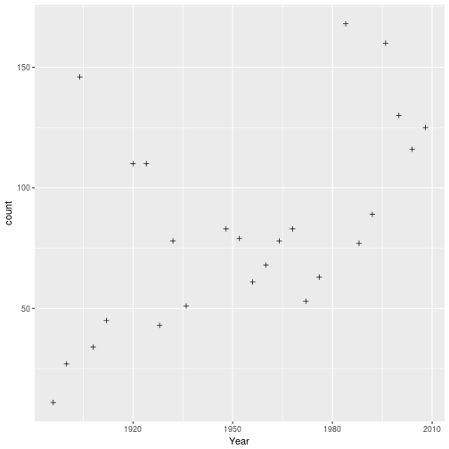

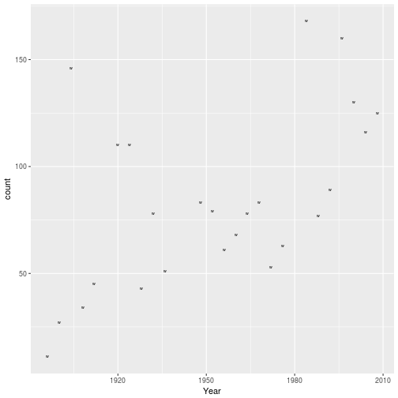

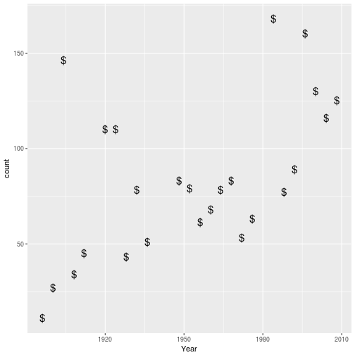

```r
ggplot(data = usa_gold_medals, aes(x = Year, y = count)) +
            geom_point(shape = 3) # ggplot2
ggplot(data = usa_gold_medals, aes(x = Year, y = count)) +
            geom_point(shape = "w") # ggplot2
ggplot(data = usa_gold_medals, aes(x = Year, y = count)) +
            geom_point(shape = "$", size=5) # ggplot2
```

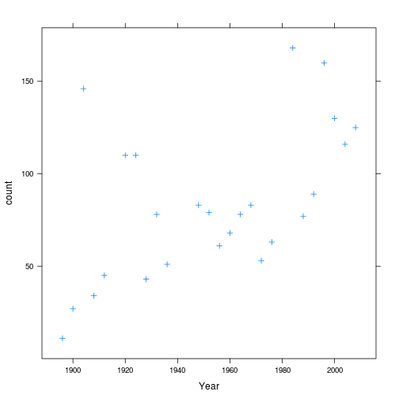

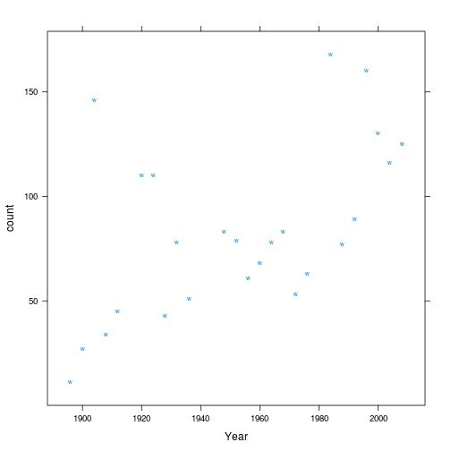

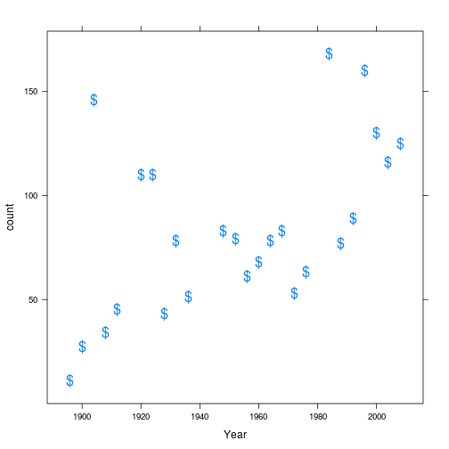

```r
xyplot(count~Year, data = usa_gold_medals, pch = 3) # lattice
xyplot(count~Year, data = usa_gold_medals, pch = "w") # lattice
xyplot(count~Year, data = usa_gold_medals, pch = "$", cex = 2) # lattice
```

#### Line Styles and Widths

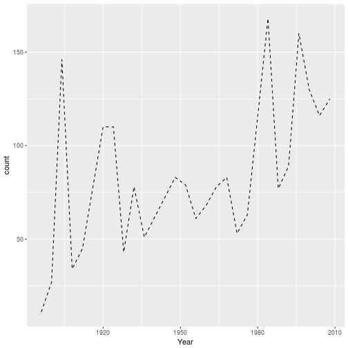

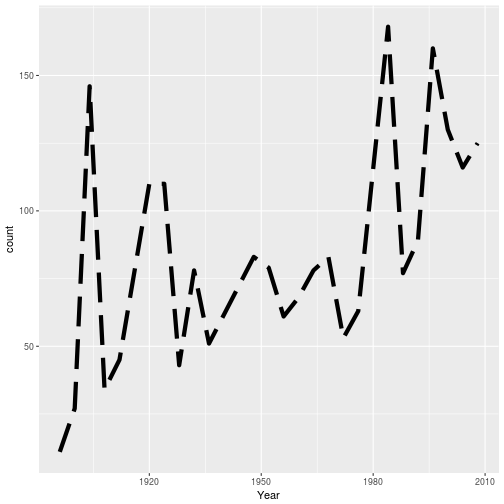

```r
ggplot(data = usa_gold_medals, aes(x = Year, y = count)) +
            geom_line(linetype = 1) # ggplot2
ggplot(data = usa_gold_medals, aes(x = Year, y = count)) +
            geom_line(linetype = 2) # ggplot2
ggplot(data = usa_gold_medals, aes(x = Year, y = count)) +
            geom_line(linetype = 5, size = 2) # ggplot2
```

[output not shown]

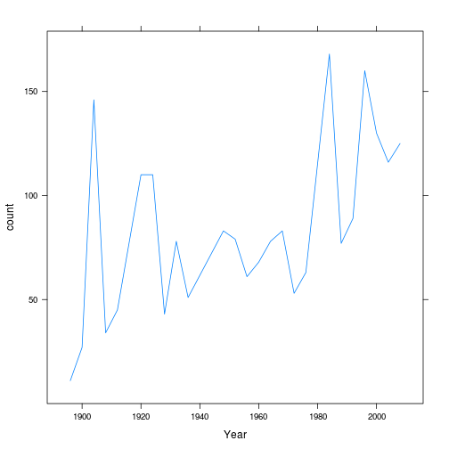

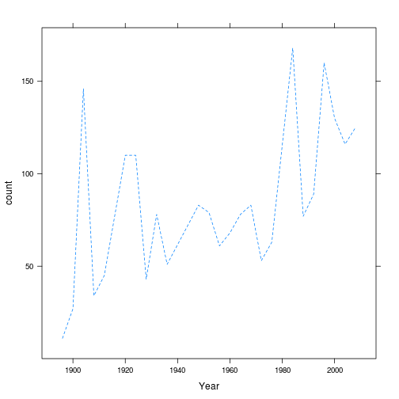

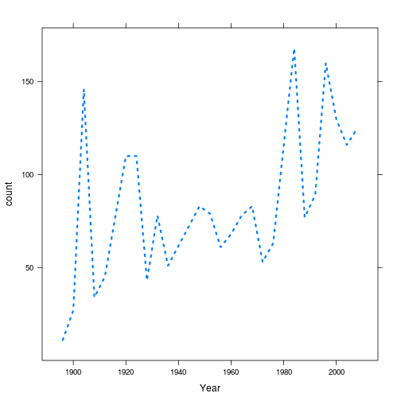

```r
xyplot(count~Year, data = usa_gold_medals, type = "l", lty = 1) # lattice
xyplot(count~Year, data = usa_gold_medals, type = "l", lty = 2) # lattice
xyplot(count~Year, data = usa_gold_medals, type = "l",
                   lty = 3, lwd = 3) # lattice
```

#### Using aesthetics to highlight features

Differences in kind

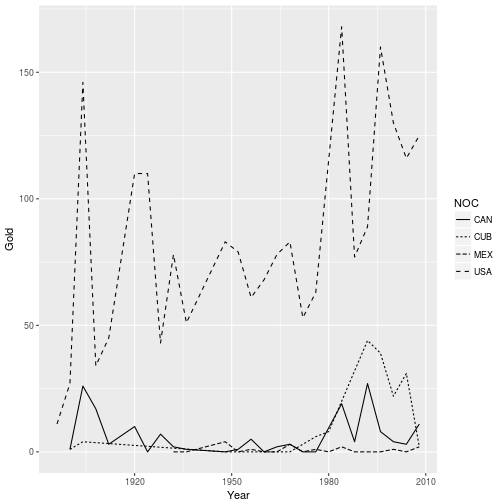

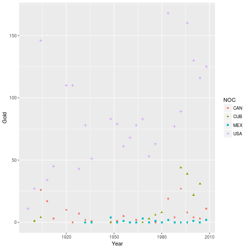

```r
ggplot(data = northern_hem, aes(x = Year, y = Gold)) +
            geom_line(aes(linetype = NOC))
ggplot(data = northern_hem, aes(x = Year, y = Gold)) +
            geom_point(aes(shape = NOC, color = NOC))
```

Differences in degree

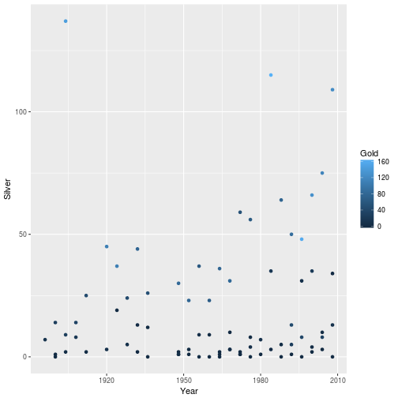

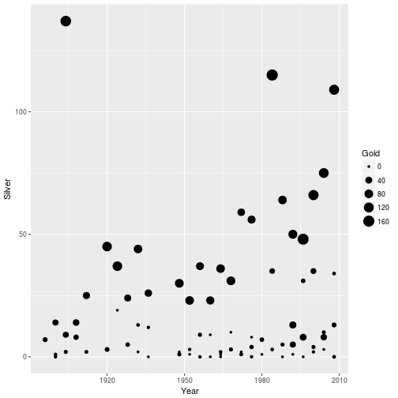

```r
ggplot(data = northern_hem, aes(x = Year, y = Silver)) +
            geom_point(aes(color = Gold))
ggplot(data = northern_hem, aes(x = Year, y = Silver)) +
            geom_point(aes(size = Gold))
```

Multiple non-coordinate aesthetics (differences in kind using color, degree using point size)

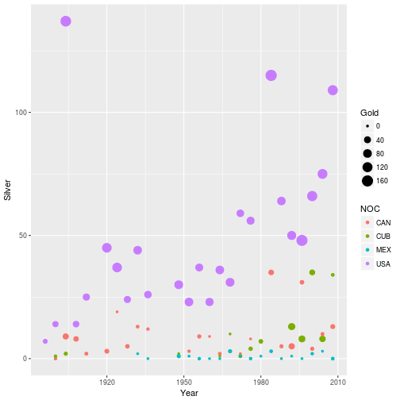

```r
ggplot(data = northern_hem, aes(x = Year, y = Silver)) +
            geom_point(aes(size = Gold, color = NOC))
```

# Fitted lines and curves with ggplot2

```r
ggplot(data = usa_gold_medals, aes(x = Year, y = count)) + geom_point()
```

[output not shown]

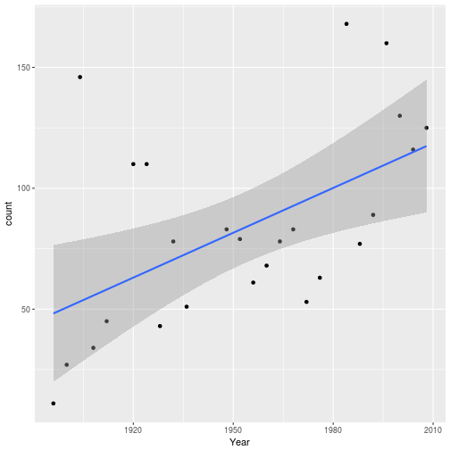

```r
# Add linear model (lm) smoother
ggplot(data = usa_gold_medals, aes(x = Year, y = count)) + geom_point() +
  geom_smooth(method = "lm")
```

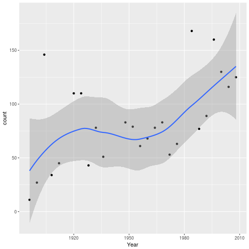

```r
# Add local linear model (loess) smoother, span of 0.75 (more smoothed)
ggplot(data = usa_gold_medals, aes(x = Year, y = count)) + geom_point() +
  geom_smooth(method = "loess", span = .75)
```

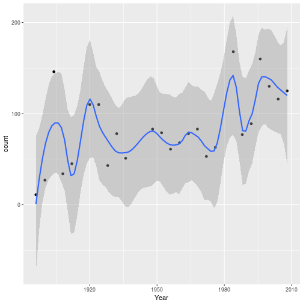

```r
# Add local linear model (loess) smoother, span of 0.25 (less smoothed)
ggplot(data = usa_gold_medals, aes(x = Year, y = count)) + geom_point() +
  geom_smooth(method = "loess", span = .25)
```

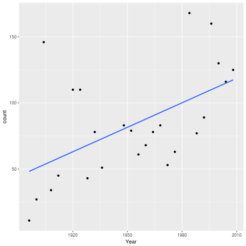

```r
# Add linear model (lm) smoother, no standard error shading
ggplot(data = usa_gold_medals, aes(x = Year, y = count)) + geom_point() +
  geom_smooth(method = "lm", se = FALSE)
```

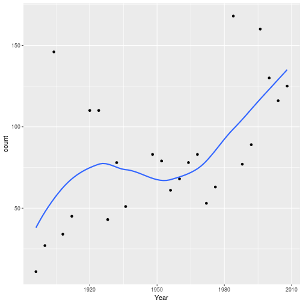

```r
# Add local linear model (loess) smoother, no standard error shading
ggplot(data = usa_gold_medals, aes(x = Year, y = count)) + geom_point() +
  geom_smooth(method = "loess", se = FALSE)
```

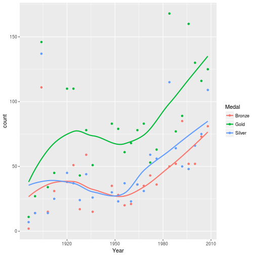

```r
# Add a local linear (loess) smoother for each medal, no standard error shading
ggplot(data = usa_all_medals, aes(x = Year, y = count)) +
  geom_point(aes(color = Medal)) +
  geom_smooth(aes(color = Medal), method = "loess", se = FALSE)
```

# lattice v. ggplot2: Combining Multiple Plots

- Both lattice and ggplot2 graphs can be combined using the *grid.arrange()* function in the **gridExtra** package

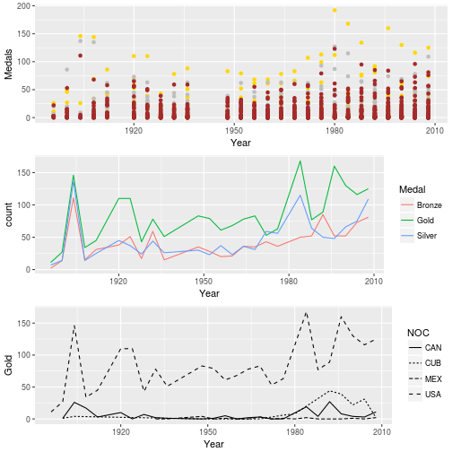

```r
# Initialize gridExtra library
library(gridExtra)

# Create 3 plots to combine in a table
plot1 <- ggplot(data = medal_counts_wide, aes(x = Year, y = Gold)) +
  geom_point(color = "gold") +
  geom_point(aes(x = Year, y = Silver), color = "gray") +
  geom_point(aes(x = Year, y = Bronze), color = "brown") +
  ylab("Medals")
plot2 <- ggplot(data = usa_all_medals, aes(x = Year, y = count)) +
      geom_line(aes(color = Medal))
plot3 <- ggplot(data = northern_hem, aes(x = Year, y = Gold)) +
      geom_line(aes(linetype = NOC))


# Call grid.arrange
grid.arrange(plot1, plot2, plot3, nrow=3, ncol = 1)
```

# Exporting

Two basic image types:

### **Raster/Bitmap** (.png, .jpeg)

Every pixel of a plot contains its own separate coding; not so great if you want to resize the image

```r
jpeg(filename = "example.jpg", width=, height=)
plot(x,y)
dev.off()
```

### **Vector** (.pdf, .ps)

Every element of a plot is encoded with a function that gives its coding conditional on several factors; great for resizing

```r
pdf(file = "example.pdf", width=, height=)
plot(x,y)
dev.off()
```

### Exporting with lattice v. ggplot

```r
# Assume we saved our plot is an object called example.plot

# lattice
trellis.device(device="pdf", filename = "example.pdf")
print(example.plot)
dev.off()

# ggplot2
ggsave(filename="example.pdf", plot=example.plot, scale=, width=, height=) # ggplot2
```

# Breakout

You're welcome to try out either lattice or ggplot for these questions, but in the solutions we'll focus on the ggplot approach.

For some of these you may want to use a smaller version of the dataset, such as a random subset, `subset <- air[sample(1:nrow(air), 10000, replace = FALSE), ]`.

### Basics

1. Plot a histogram of the flight delays with negative delays set to zero, censoring delay times at a maximum of 60 minutes.
2. Plot the arrival delay against the departure delay as a scatterplot.
3. Clean up your scatterplot with a title and axis labels. Output it as a PDF and see if you'd be comfortable with including it in a report/paper.
4. Make a boxplot of departure delays conditional on the day of week.

### Using the ideas

5. Create a trellis plot of departure delay by day of week boxplots, one subplot per destination for this subset of destinations, `DestSubset <- c('LAX','SEA','PHX','DEN','MSP','JFK','ATL','DFW','IAH', 'ORD')`. Use a 2x5 layout of panels in the plot.
6. Subset the data to flights going to Chicago (ORD) and Houston (IAH). Plot arrival delay against scheduled departure time (CRSDepTime). Now plot so that flights to Chicago are in one color and those to Houston in another. Use `scale_x_continuous()` and `scale_y_continuous()` to set the x-axis limits to be in the range from 6 am to midnight and the y-axis limits to be in the range (-10, 120).

### Advanced

7. Create a trellis plot where, for a given destination (see the subset in question 5), each panel uses a) hollow circles to plot departure delay as a function of time of day, and b) a red loess smoother without standard errors to plot the trend in departure delay over time of day. Limit the time of day shown to 6 am to midnight, and turn off the grey background. Figure out how to use partially-transparent points to reduce the effect of the overplotting of points.

# Next Module

- Module 0: Induction Slides
- Module 1: Basics Slides
- Module 2: Managingr Slides
- Module 3: Data Slides
- Module 4: Calc Slides
- Module 5: Tidyverse Slides
- Module 6: Programming Slides
- Module 7: Analysis Slides
- Module 8: Graphics Slides
- Module 9: Workflows Slides
- Module 10: Advanced Slides
- Module 11: Next Slides